# 3.3 Exercise: random intercepts and slopes regression

Benjamin Rosenbaum

October 23, 2019

We will extend the last model by including random slopes, too.

# Setup

```r
rm(list=ls())
library(rstan)
library(coda)
library(BayesianTools)
# setwd("~/Desktop/teaching Bayes")

rstan_options(auto_write = TRUE)
options(mc.cores = 3)
```

# Read dataset

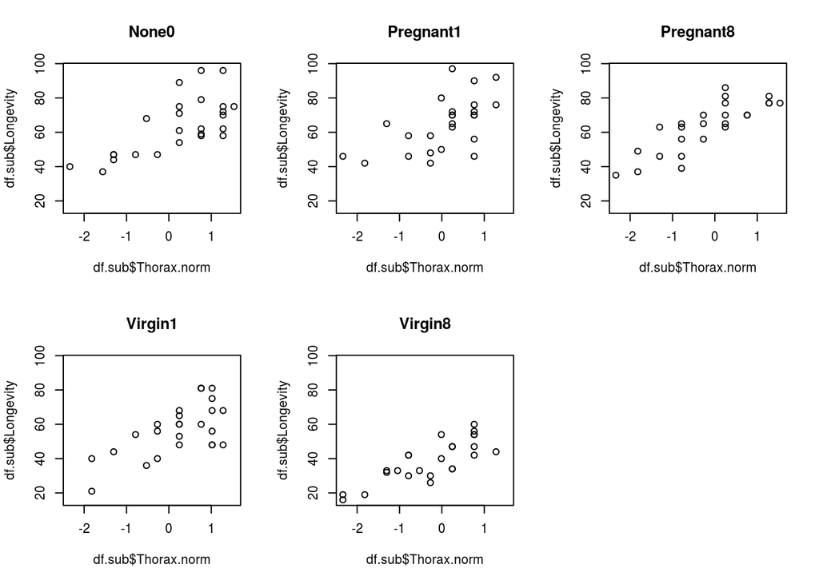

```r
df = read.csv("~/git/bayesian-intro/data/FruitflyDataReduced.csv")
df$Thorax.norm = as.numeric(scale(df$Thorax))
df$group = as.integer(df$CompanionNumber)

data = list(y = df$Longevity,
            x = df$Thorax.norm,
            group = df$group,
            n = nrow(df),
            n_group = 5)

par(mfrow=c(2,3))
for (i in 1:5){
  df.sub=subset(df, df$group==i)
  plot(df.sub$Thorax.norm,  df.sub$Longevity,
       xlim=range(df$Thorax.norm),
       ylim=range(df$Longevity),
       main=levels(df$CompanionNumber)[i]
  )
}
```

# Random intercepts and slopes regression

We will fit linear regression lines to each group (`CompanionNumber`) as follows:

$$\begin{align}
y_i & \sim \text{normal}(a_{group_i}+b_{group_i}\cdot x_i, \sigma) \quad i=1,...,n\quad (n\ \text{observations}) \\
a_j & \sim \text{normal}(\mu_a, \sigma_a) \quad j=1,...,m \quad (m\ \text{groups}) \\
b_j & \sim \text{normal}(\mu_b, \sigma_b) \quad j=1,...,m \quad (m\ \text{groups})
\end{align}$$

Here, $a_j$ and $b_j$ are group-level intercepts and slopes, which are allowed to vary (partial pooling).

Both have their own means ($\mu_a$, $\mu_b$) and standard deviations ($\sigma_a$, $\sigma_b$), which are also free parameters to be estimated.

So this is a random intercepts and slopes linear regression, lm-formulation would be `y ~ x + (x|group)`, which is short for `y ~ 1+x + (1+x|group)`.

```r
stan_code_partial = '
data {
  int n;
  int n_group;
  real y[n];
  real x[n];
  int group[n];
}
parameters {
  real a[n_group];
  real b[n_group];
  real<lower=0> sigma;
  real mu_a;
  real<lower=0> sigma_a;
  real mu_b;
  real<lower=0> sigma_b;
}
model {
  // priors
  mu_a ~ normal(0,100);
  mu_b ~ normal(0,10);
  sigma_a ~ cauchy(0,10);
  sigma_b ~ cauchy(0,10);
  for (j in 1:n_group){
    a[j] ~ normal(mu_a,sigma_a);
    b[j] ~ normal(mu_b,sigma_b);
  }
  sigma ~ normal(0,100);
  // likelihood
  for(i in 1:n){
    y[i] ~ normal(a[group[i]]+b[group[i]]*x[i], sigma);
  }
}
'

stan_model_partial = stan_model(model_code=stan_code_partial)
# save(stan_model_partial, file="stan_code_partial.RData")
# load("stan_code_partial.RData")

fit_partial  = sampling(stan_model_partial,
                        data=data,
                        chains=3,
                        iter=2000,
                        warmup=1000
)
```

```
## Warning: Examine the pairs() plot to diagnose sampling problems
```

```
## Warning: The largest R-hat is 1.24, indicating chains have not mixed.
## Running the chains for more iterations may help. See
## http://mc-stan.org/misc/warnings.html#r-hat
```

```
## Warning: Bulk Effective Samples Size (ESS) is too low, indicating posterior means and medians may be unreliable.
## Running the chains for more iterations may help. See
## http://mc-stan.org/misc/warnings.html#bulk-ess
```

```
## Warning: Tail Effective Samples Size (ESS) is too low, indicating posterior variances and tail quantiles may be unreliable.
## Running the chains for more iterations may help. See
## http://mc-stan.org/misc/warnings.html#tail-ess
```

```r
fit_partial  = sampling(stan_model_partial,
                        data=data,
                        chains=3,
                        iter=2000,
                        warmup=1000,
                        control=list(adapt_delta=0.999)
)
```

```
## Warning: There were 14 divergent transitions after warmup. Increasing adapt_delta above 0.999 may help. See
## http://mc-stan.org/misc/warnings.html#divergent-transitions-after-warmup
```

```
## Warning: Examine the pairs() plot to diagnose sampling problems
```

```
## Warning: Bulk Effective Samples Size (ESS) is too low, indicating posterior means and medians may be unreliable.
## Running the chains for more iterations may help. See
## http://mc-stan.org/misc/warnings.html#bulk-ess
```

```r
print(fit_partial, digits=3, probs=c(0.025, 0.975))
```

```
## Inference for Stan model: a4468f93ab94825f5a5f20718fbcbdbf.
## 3 chains, each with iter=2000; warmup=1000; thin=1;
## post-warmup draws per chain=1000, total post-warmup draws=3000.
##
##             mean se_mean    sd     2.5%    97.5% n_eff  Rhat
## a[1]      61.372   0.043 2.105   57.329   65.491  2391 1.000
## a[2]      63.841   0.042 2.122   59.623   67.996  2498 1.001
## a[3]      65.120   0.045 2.204   60.747   69.424  2441 1.000
## a[4]      54.670   0.036 2.112   50.416   58.748  3398 0.999
## a[5]      42.232   0.044 2.159   38.036   46.645  2379 1.000
## b[1]      10.431   0.037 1.384    7.643   13.147  1401 1.001
## b[2]      10.356   0.041 1.439    7.291   13.220  1219 1.004
## b[3]      10.668   0.037 1.378    8.051   13.727  1423 1.002
## b[4]      10.454   0.039 1.423    7.636   13.295  1352 1.006
## b[5]      10.286   0.040 1.412    7.319   12.995  1258 1.002
## sigma     10.686   0.015 0.731    9.380   12.193  2331 1.000
## mu_a      57.308   0.131 5.721   45.733   68.741  1898 1.000
## sigma_a   11.505   0.132 4.769    5.704   23.561  1300 1.002
## mu_b      10.389   0.040 1.262    7.946   12.944  1008 1.002
## sigma_b    1.376   0.056 1.187    0.120    4.450   455 1.008
## lp__    -370.616   0.320 4.821 -379.618 -360.266   227 1.019
##
## Samples were drawn using NUTS(diag_e) at Mon Oct 14 14:24:34 2019.
## For each parameter, n_eff is a crude measure of effective sample size,
## and Rhat is the potential scale reduction factor on split chains (at
## convergence, Rhat=1).
```

```
## ci_level: 0.8 (80% intervals)
```

```
## outer_level: 0.95 (95% intervals)
```

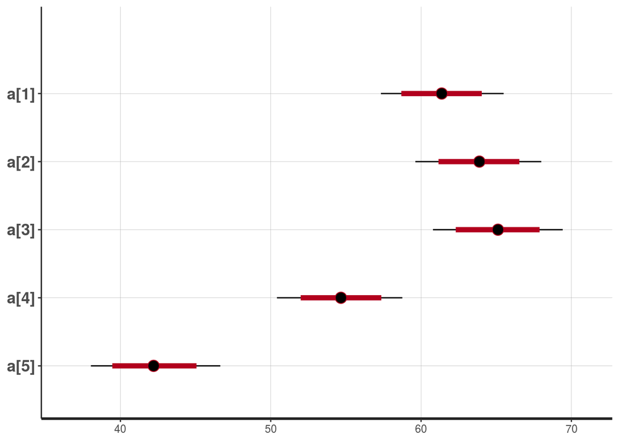

```r
# plot(fit_partial)
plot(fit_partial, pars="a")
```

```
## ci_level: 0.8 (80% intervals)
## outer_level: 0.95 (95% intervals)
```

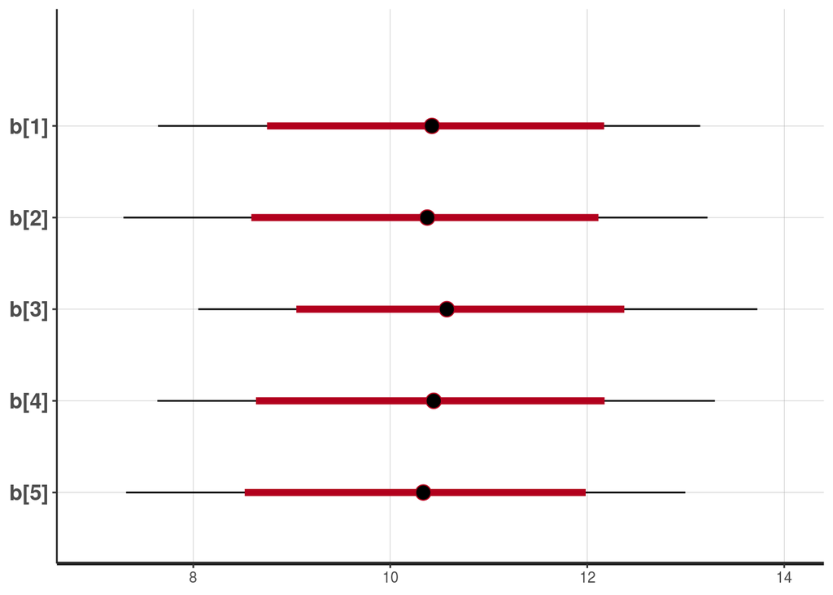

```r
plot(fit_partial, pars="b")
```

```r
# plot(As.mcmc.list(fit_partial)) # from coda package

# pairs(fit_partial, pars=c("b","mu_b","sigma_b"))

posterior=as.matrix(fit_partial)
```

There does not seem to be much evidence that the slopes are different between groups!

# Predictions / credible intervals

Again, we can generate predictions and compute credible intervals (for the deterministic part of the model)

(Here: 90% credible intervals)

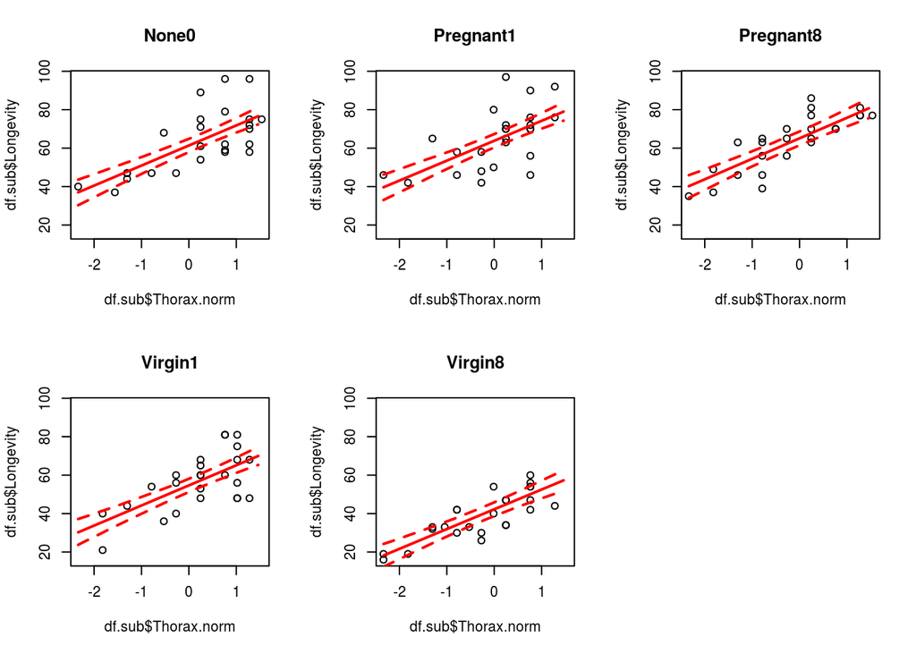

```r
x.pred = seq(from=min(df$Thorax.norm), to=max(df$Thorax.norm), by=0.1)

par(mfrow=c(2,3))

for (i in 1:5){
  df.sub=subset(df, df$group==i)
  plot(df.sub$Thorax.norm,  df.sub$Longevity,
       xlim=range(df$Thorax.norm),
       ylim=range(df$Longevity),
       main=levels(df$CompanionNumber)[i]
  )

  y.cred = matrix(0, nrow=nrow(posterior), ncol=length(x.pred))
  for(j in 1:nrow(posterior)){
    y.cred[j, ] = posterior[j,paste0("a[",i,"]")] + posterior[j,paste0("b[",i,"]")]*x.pred
  }

  y.cred.mean = apply(y.cred, 2, function(x) mean(x))
  lines(x.pred, y.cred.mean, col="red", lwd=2)

  y.cred.q05 = apply(y.cred, 2, function(x) quantile(x, probs=0.05))
  lines(x.pred, y.cred.q05, col="red", lwd=2, lty=2)

  y.cred.q95 = apply(y.cred, 2, function(x) quantile(x, probs=0.95))
  lines(x.pred, y.cred.q95, col="red", lwd=2, lty=2)
}
```

# Further reading

Read more about complete pooling, partial pooling, no pooling and shrinkage:

https://www.tjmahr.com/plotting-partial-pooling-in-mixed-effects-models/